# Hormone Receptor Gene Expression

Sneha Chaturvedi, Emma Jones

2026-08-18

## Goals

Examine expression of gonadal hormone receptor genes across cell types in the fetal brain snRNA-seq dataset.

**Receptors examined:**

- **Nuclear receptors:** AR, ESR1, ESR2, PGR
- **Membrane progesterone receptors:** PAQR5, PAQR7, PAQR8, PGRMC1, PGRMC2
- **Membrane estrogen receptor:** GPER1 - not found
- **Membrane androgen receptor:** ZIP9 (SLC39A9) - not found

## Set Up

```r
Packages <- c(
  "tidyverse", "Seurat", "Signac", "glue", "readxl", "cowplot",
  "edgeR", "limma", "patchwork", "svglite", "Matrix", "viridis",
  "ggrepel", "scales"
)
lapply(Packages, library, character.only = TRUE)
source("pseudobulk_functions.R")

set.seed(123)
```

```r
SSD_data <- readRDS("../../data/cache/receptor_expr_object.rds")
DefaultAssay(SSD_data) <- "RNA"
Idents(SSD_data)       <- "celltype"
```

## Restrict to Cell Types in the Hormone–Gene Analysis

Receptor plots are restricted to the cell types that actually entered the hormone–gene limma models, so receptor expression is shown only where a hormone–gene association could have been detected. The cell type set is read from the base-model result tables (union across TT, E2, P4) rather than hard-coded, so it stays in sync if the models are rerun.

```r
HORMONE_RESULT_FILES <- c(
  TT = "../../results/gene-hormone/testosterone_genes/run_voom_lm/TT_base_results.csv",
  E2 = "../../results/gene-hormone/estradiol_genes/run_voom_lm/E2_base_results.csv",
  P4 = "../../results/gene-hormone/progesterone_genes/run_voom_lm/P4_base_results.csv"
)
N_EXPECTED_CELLTYPES <- 11

stopifnot(all(file.exists(HORMONE_RESULT_FILES)))

# Per-analysis cell type sets, kept separate so partial coverage can be flagged
CT_BY_ANALYSIS <- HORMONE_RESULT_FILES %>%
  purrr::map(~ readr::read_csv(.x, show_col_types = FALSE)) %>%
  purrr::map(~ sort(unique(as.character(.x$cell_type))))

ANALYSIS_CELLTYPES <- sort(unique(unlist(CT_BY_ANALYSIS, use.names = FALSE)))

# How many of the three models each cell type contributed to
ct_coverage <- tibble::tibble(celltype = ANALYSIS_CELLTYPES) %>%
  dplyr::mutate(
    analyses  = purrr::map_chr(
      celltype,
      ~ paste(names(CT_BY_ANALYSIS)[purrr::map_lgl(CT_BY_ANALYSIS, function(s) .x %in% s)],
              collapse = ", ")
    ),
    n_analyses = purrr::map_int(
      celltype,
      ~ sum(purrr::map_lgl(CT_BY_ANALYSIS, function(s) .x %in% s))
    ),
    partial   = n_analyses < length(CT_BY_ANALYSIS)
  )

cat("Cell types in hormone-gene analysis:", length(ANALYSIS_CELLTYPES), "\n")
```

```
Cell types in hormone-gene analysis: 12
```

```r
print(ct_coverage, n = Inf)
```

```
# A tibble: 12 × 4
   celltype           analyses   n_analyses partial
   <chr>              <chr>           <int> <lgl>
 1 Astrocyte-Immature TT, E2, P4          3 FALSE
 2 EN-IT-Immature     TT, E2, P4          3 FALSE
 3 EN-L5_6-NP         TT                  1 TRUE
 4 EN-L6-IT           TT, E2, P4          3 FALSE
 5 EN-L6b             TT, E2, P4          3 FALSE
 6 EN-Newborn         TT, E2, P4          3 FALSE
 7 EN-Non-IT-Immature TT, E2, P4          3 FALSE
 8 IN-CGE-Immature    TT, E2, P4          3 FALSE
 9 IN-MGE-Immature    TT, E2, P4          3 FALSE
10 IN-MGE-SST         TT, E2, P4          3 FALSE
11 IPC-EN             TT, E2, P4          3 FALSE
12 OPC                TT                  1 TRUE
```

```r
if (length(ANALYSIS_CELLTYPES) != N_EXPECTED_CELLTYPES) {
  warning("Expected ", N_EXPECTED_CELLTYPES, " cell types, found ",
          length(ANALYSIS_CELLTYPES),
          " — check that the result files match the current models.")
}

missing_ct <- setdiff(ANALYSIS_CELLTYPES, unique(as.character(SSD_data$celltype)))
if (length(missing_ct) > 0) {
  warning("Cell types absent from the Seurat object: ",
          paste(missing_ct, collapse = ", "))
}
```

```r
SSD_sub <- subset(SSD_data, subset = celltype %in% ANALYSIS_CELLTYPES)

# Drop unused levels so empty cell types do not appear on plot axes / legends
SSD_sub$celltype <- factor(as.character(SSD_sub$celltype),
                           levels = ANALYSIS_CELLTYPES)
Idents(SSD_sub) <- "celltype"

cat(sprintf("Cells retained: %d / %d (%.1f%%)\n",
            ncol(SSD_sub), ncol(SSD_data),
            100 * ncol(SSD_sub) / ncol(SSD_data)))
```

```
Cells retained: 110792 / 126489 (87.6%)
```

```r
receptor_genes <- c(
  "ESR1", "ESR2", "PGR", "AR",
  "FSHR", "LHCGR", "GNRHR",
  "PTGER1", "PTGER2", "PTGER3", "PTGER4",
  "THRA", "THRB",
  "PAQR7", "PAQR8", "PAQR5", "PGRMC1", "PGRMC2"
)

# Confirm which genes are present in the assay
cat("Receptor genes in assay:",
    sum(receptor_genes %in% rownames(SSD_data)), "/", length(receptor_genes), "\n")
```

```
Receptor genes in assay: 18 / 18
```

```r
cat("Missing:", setdiff(receptor_genes, rownames(SSD_data)), "\n")
```

```
Missing:
```

## UMAP — Analysis Coverage

Points are rasterized at 600 dpi while text, labels, and axes stay vector, which keeps the SVG editable in Illustrator without tens of thousands of individual point objects.

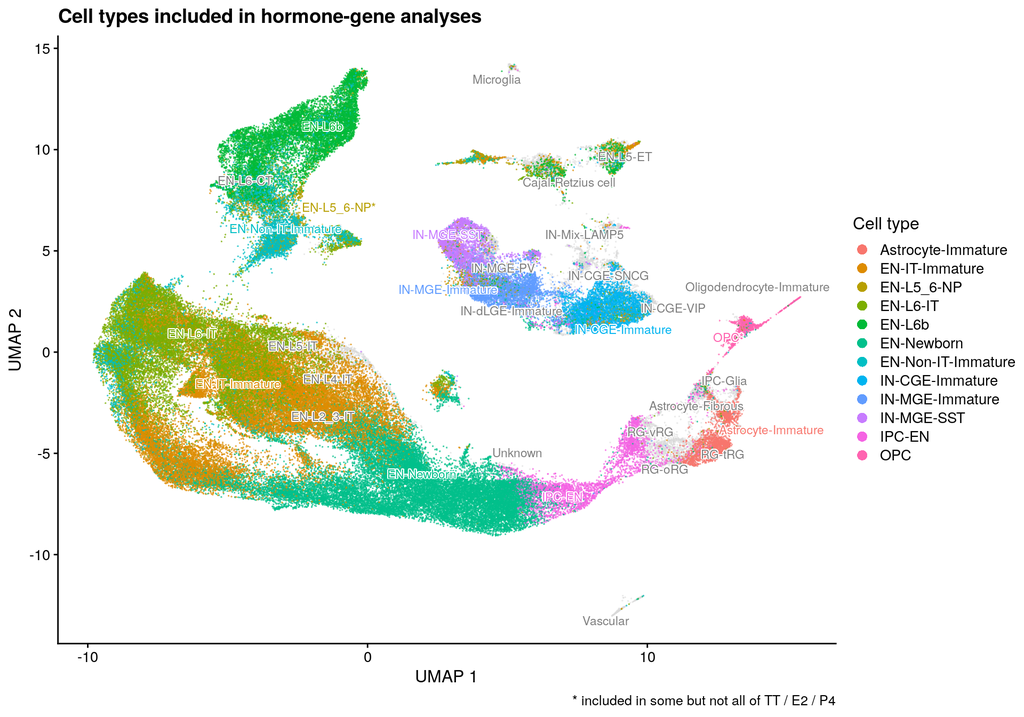

```r
REDUCTION   <- if ("umap.rna" %in% SeuratObject::Reductions(SSD_data)) {
  "umap.rna"
} else {
  SeuratObject::DefaultDimReduc(SSD_data)
}
RASTER_DPI        <- 600    # rasterization resolution for point layers
PT_SIZE           <- 0.2
MAX_CELLS_NORASTR <- 20000  # fallback subsample if ggrastr is unavailable

emb <- SeuratObject::Embeddings(SSD_data, reduction = REDUCTION)[, 1:2] %>%
  as.data.frame() %>%
  setNames(c("dim1", "dim2")) %>%
  dplyr::mutate(
    celltype = as.character(SSD_data$celltype),
    included = celltype %in% ANALYSIS_CELLTYPES
  )

# Colors assigned over ANALYSIS_CELLTYPES only, so they match the subset DimPlot
ct_colors <- setNames(scales::hue_pal()(length(ANALYSIS_CELLTYPES)),
                      ANALYSIS_CELLTYPES)

# Centroids computed on ALL cells so label positions match the full UMAP
label_df <- emb %>%
  dplyr::group_by(celltype, included) %>%
  dplyr::summarise(dim1 = median(dim1), dim2 = median(dim2), .groups = "drop") %>%
  dplyr::left_join(dplyr::select(ct_coverage, celltype, partial, n_analyses),
                   by = "celltype") %>%
  dplyr::mutate(
    partial = tidyr::replace_na(partial, FALSE),
    label   = paste0(celltype, ifelse(partial, "*", "")),
    color   = ifelse(included, ct_colors[celltype], "grey50")
  )

has_rastr <- requireNamespace("ggrastr", quietly = TRUE)
if (!has_rastr) {
  warning("ggrastr not installed — subsampling to ", MAX_CELLS_NORASTR,
          " cells instead of rasterizing.")
  set.seed(123)
  emb <- emb[sample(nrow(emb), min(nrow(emb), MAX_CELLS_NORASTR)), ]
}

p_coverage_umap <- ggplot(mapping = aes(dim1, dim2)) +
  geom_point(data = dplyr::filter(emb, !included),
             color = "grey85", size = PT_SIZE, shape = 16, alpha = 0.5) +
  geom_point(data = dplyr::filter(emb, included),
             aes(color = celltype), size = PT_SIZE, shape = 16, alpha = 0.7) +
  scale_color_manual(values = ct_colors, breaks = ANALYSIS_CELLTYPES,
                     name = "Cell type") +
  ggrepel::geom_text_repel(data = label_df,
                           aes(label = label), color = label_df$color,
                           size = 3, box.padding = 0.3, max.overlaps = Inf,
                           bg.color = "white", bg.r = 0.1, seed = 123) +
  guides(color = guide_legend(override.aes = list(size = 3, alpha = 1))) +
  cowplot::theme_cowplot(12) +
  labs(x = "UMAP 1", y = "UMAP 2",
       title = "Cell types included in hormone-gene analyses",
       caption = "* included in some but not all of TT / E2 / P4")

if (has_rastr) {
  p_coverage_umap <- ggrastr::rasterise(p_coverage_umap,
                                        layers = "Point", dpi = RASTER_DPI)
}
p_coverage_umap
```

## Cell Type UMAP

```r
p_dimplot <- DimPlot(SSD_sub, group.by = "celltype", label = TRUE, repel = TRUE) +
  theme(legend.position = "right") +
  ggtitle(sprintf("Cell types in hormone-gene analysis (n = %d)",
                  length(ANALYSIS_CELLTYPES)))
p_dimplot
```

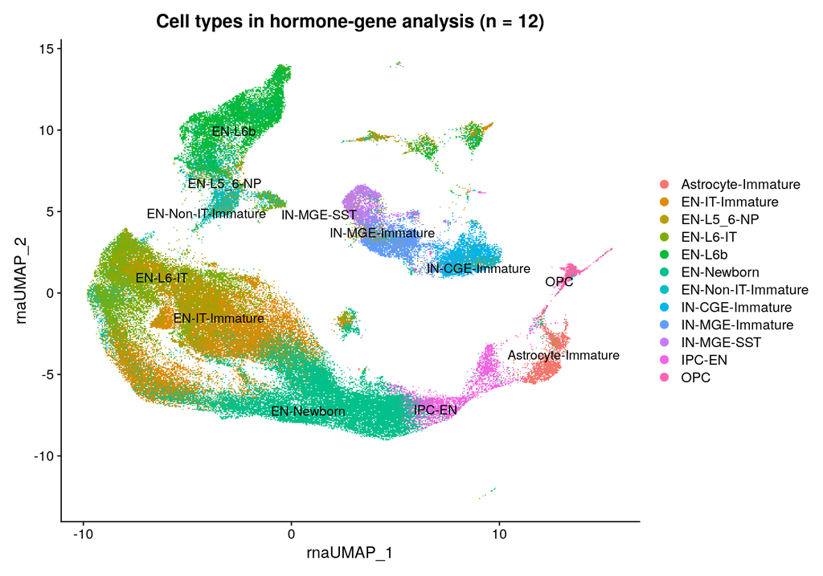

## VlnPlots — Key Nuclear Receptors

- AR
- ESR1
- ESR2
- PGR

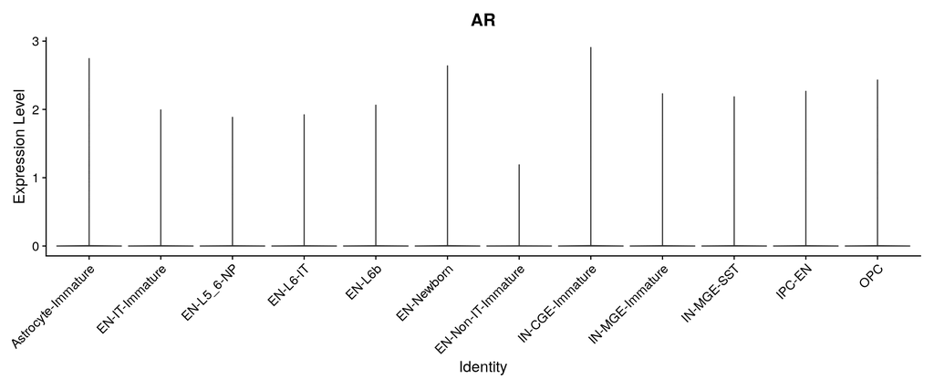

```r
p_vln_ar <- VlnPlot(SSD_sub, features = "AR", group.by = "celltype", pt.size = 0) +
  theme(axis.text.x = element_text(angle = 45, hjust = 1),
        legend.position = "none")
p_vln_ar
```

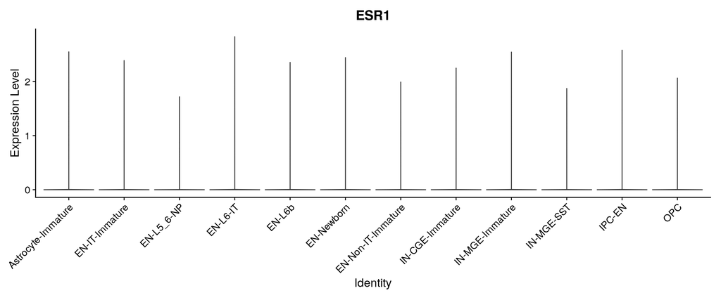

```r
p_vln_esr1 <- VlnPlot(SSD_sub, features = "ESR1", group.by = "celltype", pt.size = 0) +
  theme(axis.text.x = element_text(angle = 45, hjust = 1),
        legend.position = "none")
p_vln_esr1
```

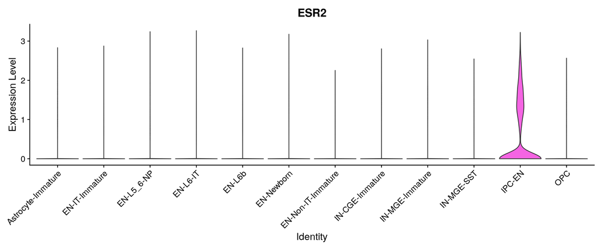

```r
p_vln_esr2 <- VlnPlot(SSD_sub, features = "ESR2", group.by = "celltype", pt.size = 0) +
  theme(axis.text.x = element_text(angle = 45, hjust = 1),
        legend.position = "none")
p_vln_esr2
```

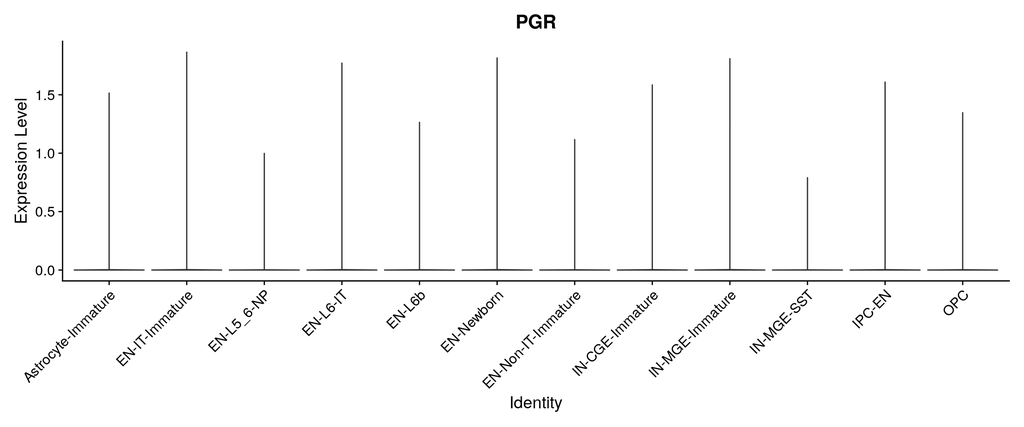

```r
p_vln_pgr <- VlnPlot(SSD_sub, features = "PGR", group.by = "celltype", pt.size = 0) +
  theme(axis.text.x = element_text(angle = 45, hjust = 1),
        legend.position = "none")
p_vln_pgr
```

## FeaturePlots — Key Nuclear Receptors

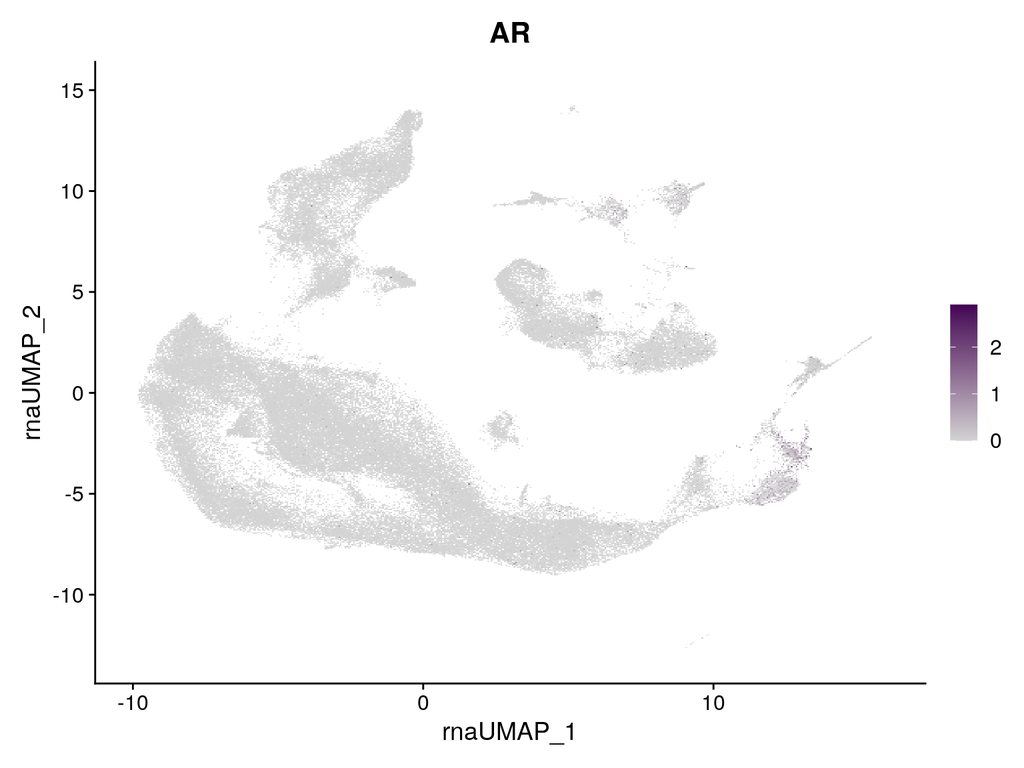

```r
p_feat_ar <- FeaturePlot(SSD_sub, features = "AR",
            cols = c("lightgrey", "#440154FF"), alpha = 0.7)
p_feat_ar
```

### ESR1

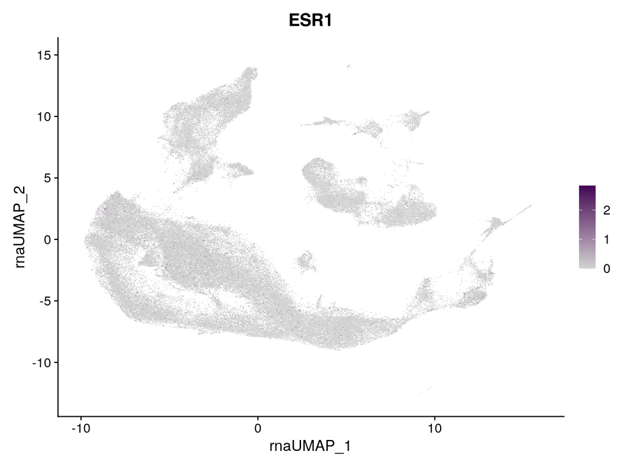

```r
p_feat_esr1 <- FeaturePlot(SSD_sub, features = "ESR1",
            cols = c("lightgrey", "#440154FF"), alpha = 0.7)
p_feat_esr1
```

### ESR2

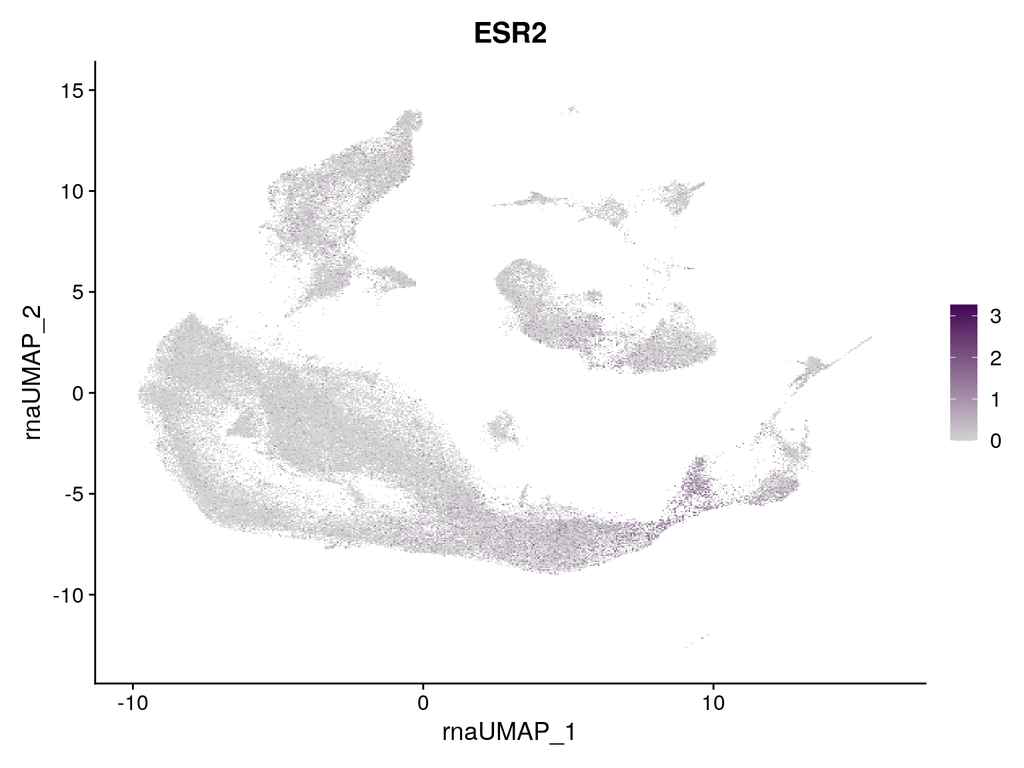

```r
p_feat_esr2 <- FeaturePlot(SSD_sub, features = "ESR2",
            cols = c("lightgrey", "#440154FF"), alpha = 0.7)
p_feat_esr2
```

### PGR

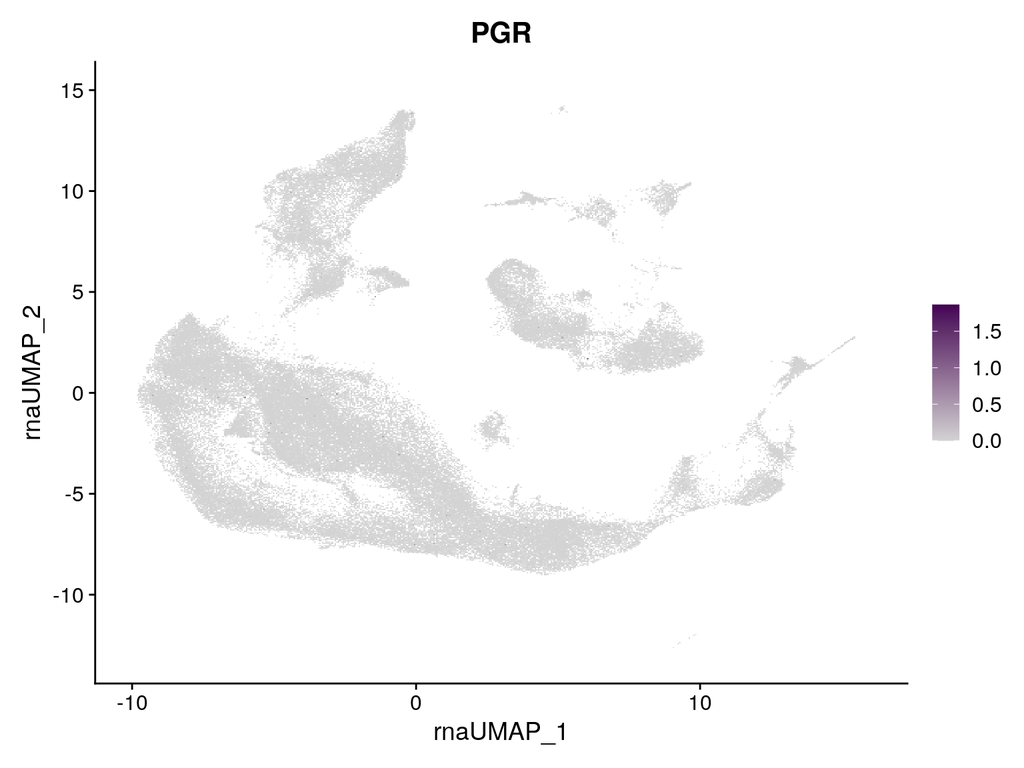

```r
p_feat_pgr <- FeaturePlot(SSD_sub, features = "PGR",
            cols = c("lightgrey", "#440154FF"), alpha = 0.7)
p_feat_pgr
```

## VlnPlots — Membrane P4 Receptors: PAQR

```r
p_vln_paqr <- VlnPlot(SSD_sub, features = c("PAQR5", "PAQR7", "PAQR8"),
                      group.by = "celltype", pt.size = 0, ncol = 3) &
  theme(axis.text.x = element_text(angle = 45, hjust = 1),
        legend.position = "none")
p_vln_paqr
```

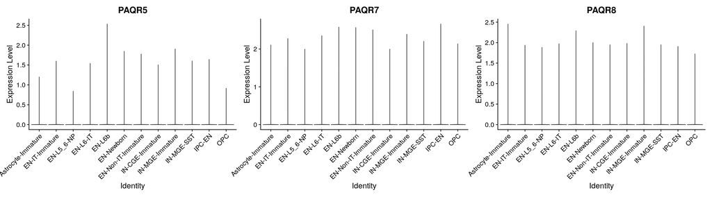

## FeaturePlots — Membrane P4 Receptors: PAQR

```r
p_feat_paqr <- FeaturePlot(SSD_sub, features = c("PAQR5", "PAQR7", "PAQR8"),
            cols = c("lightgrey", "#440154FF"), alpha = 0.7, ncol = 3)
p_feat_paqr
```

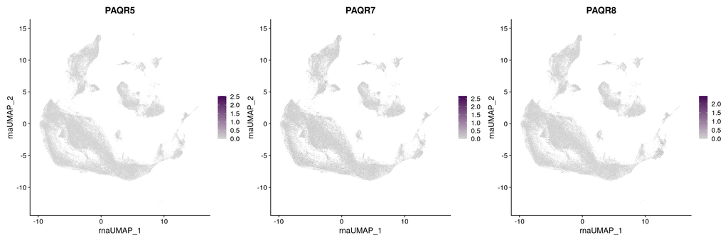

## VlnPlots — Membrane P4 Receptors: PGRMC

```r
p_vln_pgrmc <- VlnPlot(SSD_sub, features = c("PGRMC1", "PGRMC2"),
                       group.by = "celltype", pt.size = 0, ncol = 2) &
  theme(axis.text.x = element_text(angle = 45, hjust = 1),
        legend.position = "none")
p_vln_pgrmc
```

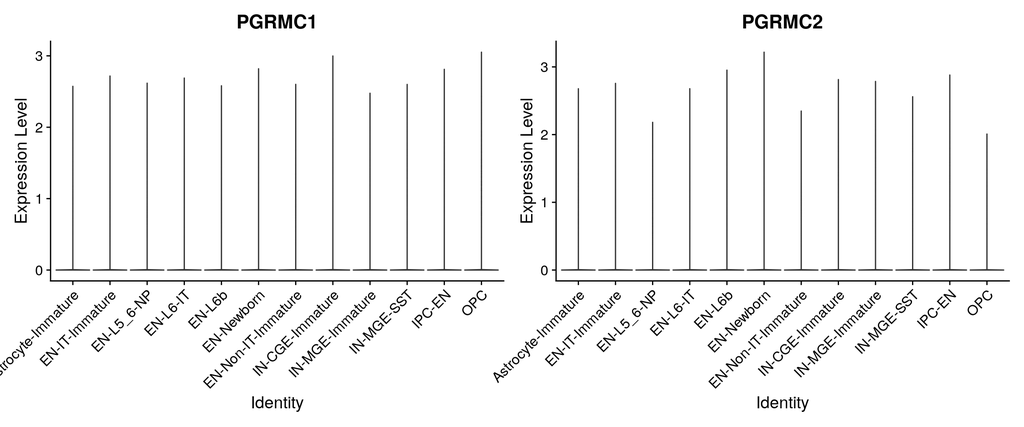

## FeaturePlots — Membrane P4 Receptors: PGRMC

```r
p_feat_pgrmc <- FeaturePlot(SSD_sub, features = c("PGRMC1", "PGRMC2"),
            cols = c("lightgrey", "#440154FF"), alpha = 0.7, ncol = 2)
p_feat_pgrmc
```

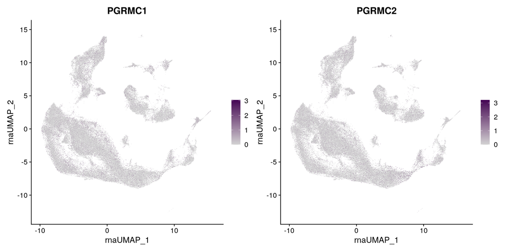

## ESR2 Expression by Cell Type

Percentage of ESR2-expressing cells per cell type at three expression thresholds (applied to the log-normalized RNA data layer).

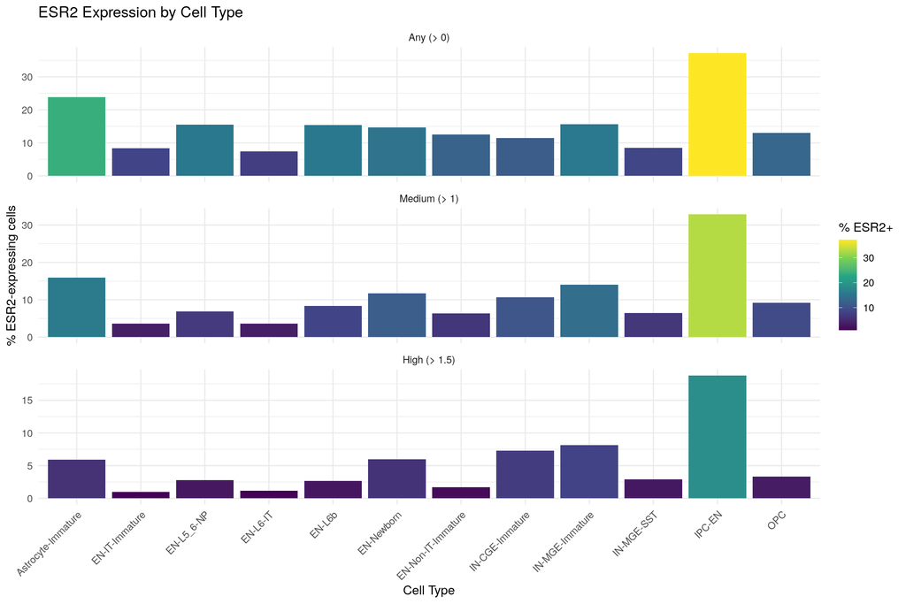

```r
esr2_expr <- as.numeric(
  GetAssayData(SSD_sub, assay = "RNA", layer = "data")["ESR2", ]
)
SSD_sub$esr2_expr <- esr2_expr

esr2_pct <- SSD_sub@meta.data %>%
  dplyr::group_by(celltype) %>%
  dplyr::summarise(
    `Any (> 0)`    = mean(esr2_expr > 0)   * 100,
    `Medium (> 1)` = mean(esr2_expr > 1)   * 100,
    `High (> 1.5)` = mean(esr2_expr > 1.5) * 100,
    .groups = "drop"
  ) %>%
  tidyr::pivot_longer(cols = -celltype,
                      names_to = "threshold", values_to = "pct") %>%
  dplyr::mutate(threshold = factor(threshold,
                                   levels = c("Any (> 0)", "Medium (> 1)", "High (> 1.5)")))

p_esr2_pct <- ggplot(esr2_pct, aes(x = celltype, y = pct, fill = pct)) +
  geom_bar(stat = "identity") +
  facet_wrap(~ threshold, ncol = 1, scales = "free_y") +
  scale_fill_viridis_c() +
  theme_minimal(base_size = 12) +
  theme(axis.text.x = element_text(angle = 45, hjust = 1),
        legend.position = "right") +
  labs(x = "Cell Type", y = "% ESR2-expressing cells",
       fill = "% ESR2+",
       title = "ESR2 Expression by Cell Type")
p_esr2_pct
```

## Save Plots

```r
out_dir <- "../../results/gene-hormone/single_cell_plots_analysis_celltypes"

dir.create(out_dir, showWarnings = FALSE, recursive = TRUE)

# Record the exact cell type set used for these figures
readr::write_csv(
  ct_coverage,
  file.path(out_dir, "analysis_celltypes.csv")
)

save_dual_format(p_coverage_umap, out_dir, "celltype_umap_analysis_coverage", width = 10, height = 7)
save_dual_format(p_dimplot,    out_dir, "celltype_umap",             width = 10, height = 7)
save_dual_format(p_vln_ar,     out_dir, "vln_AR",                    width = 12, height = 5)
save_dual_format(p_vln_esr1,   out_dir, "vln_ESR1",                  width = 12, height = 5)
save_dual_format(p_vln_esr2,   out_dir, "vln_ESR2",                  width = 12, height = 5)
save_dual_format(p_vln_pgr,    out_dir, "vln_PGR",                   width = 12, height = 5)
save_dual_format(p_feat_ar,    out_dir, "feat_AR",                    width = 8,  height = 6)
save_dual_format(p_feat_esr1,  out_dir, "feat_ESR1",                  width = 8,  height = 6)
save_dual_format(p_feat_esr2,  out_dir, "feat_ESR2",                  width = 8,  height = 6)
save_dual_format(p_feat_pgr,   out_dir, "feat_PGR",                   width = 8,  height = 6)
save_dual_format(p_vln_paqr,   out_dir, "vln_PAQR",                    width = 18, height = 5)
save_dual_format(p_feat_paqr,  out_dir, "feat_PAQR",                    width = 18, height = 6)
save_dual_format(p_vln_pgrmc,  out_dir, "vln_PGRMC",                   width = 12, height = 5)
save_dual_format(p_feat_pgrmc, out_dir, "feat_PGRMC",                   width = 12, height = 6)
save_dual_format(p_esr2_pct,   out_dir, "esr2_pct_by_celltype",        width = 12, height = 8)
```